# STATS 7022 - Data Science Diamonds Analysis Assignment 2: Question 1

Max Glonek

Trimester 2, 2024

# 1 Load Libraries

# 2 Load Data

The data is contained within the file `diamonds.rds`. The data is read in to `R`.

There are 28,274 rows in the `diamonds` data.

# 3 Data Cleaning and Pre-processing

## 3.1 Remove Missing Prices and Volumes

Some rows are missing a `price` or `volume`. These rows are removed from the data.

There are now 28,073 rows in the `diamonds` data.

## 3.2 Derive Cut, Colour, and Clarity

### 3.2.1 Cut

The *first* character of the variable `c.grade` contains information about the cut of diamonds, according to the following scheme:

| **c.grade** | **cut** |
| --- | --- |
| 1 | premium |
| 2 | ideal |

We derive `cut` from the first character of `c.grade`. Results are summarised in Table 3.1.

Table 3.1: Number of diamonds, by cut quality.

| cut | count |
| --- | --- |
| ideal | 17149 |
| premium | 10924 |

### 3.2.2 Colour

The *second* character of the variable `c.grade` contains information about the colour of diamonds.

We derive `colour` from the second character of `c.grade`. Results are summarised in Table 3.2.

Table 3.2: Number of diamonds, by colour.

| colour | count |
| --- | --- |
| T | 1360 |
| U | 2788 |
| V | 4397 |
| W | 6155 |
| X | 4840 |
| Y | 4989 |
| Z | 3544 |

### 3.2.3 Clarity

The *third* character of the variable `c.grade` contains information about the clarity of diamonds, according to the following scheme:

[output not shown]

We derive `clarity` from the third character of `c.grade`. Results are summarised in Table 3.3.

Table 3.3: Number of diamonds, by clarity.

| clarity | count |
| --- | --- |
| I1 | 267 |
| IF | 1122 |
| SI1 | 6265 |
| SI2 | 4421 |
| VS1 | 4396 |
| VS2 | 6698 |
| VVS1 | 2118 |
| VVS2 | 2786 |

## 3.3 Select Variables

We only need the following columns:

- `cut`
- `price`
- `volume`

All other columns are removed.

## 3.4 Convert Cut to Categorical

We convert `cut` to a categorical variable.

# 4 Models

We create two separate workflows using `tidymodels`:

1. A logistic regression model with `cut` as the response variable and `price` as the predictor.

```
## ══ Workflow ════════════════════════════════════════════════════════════════════
## Preprocessor: Recipe
## Model: logistic_reg()
##
## ── Preprocessor ────────────────────────────────────────────────────────────────
## 1 Recipe Step
##
## • step_normalize()
##
## ── Model ───────────────────────────────────────────────────────────────────────
## Logistic Regression Model Specification (classification)
##
## Computational engine: glm
```

2. A logistic regression model with `cut` as the response variable and `volume` as the predictor.

```
## ══ Workflow ════════════════════════════════════════════════════════════════════
## Preprocessor: Recipe
## Model: logistic_reg()
##
## ── Preprocessor ────────────────────────────────────────────────────────────────
## 1 Recipe Step
##
## • step_normalize()
##
## ── Model ───────────────────────────────────────────────────────────────────────
## Logistic Regression Model Specification (classification)
##
## Computational engine: glm
```

Both models are fitted to the `diamonds` data, with ROC curves displayed in Figure 5.1.

# 5 ROC Curves

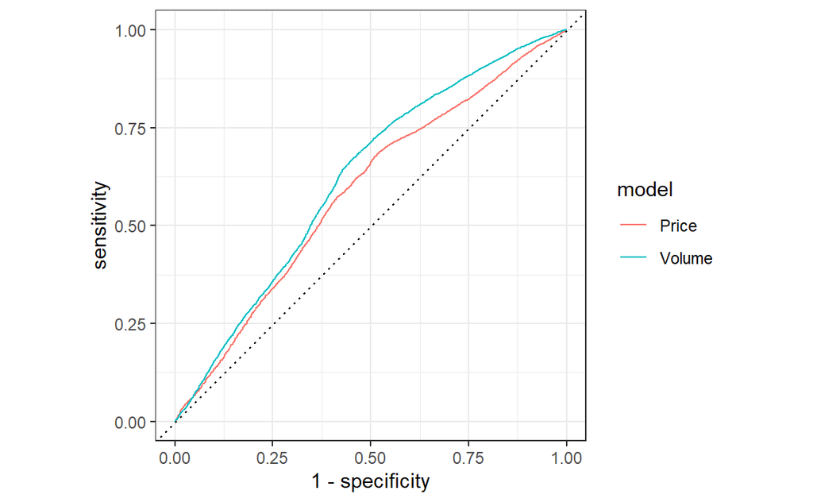

Figure 5.1: ROC Curves for logistic regression models.